# Final Project

Xintong Guan

5/11/2017

Is it really a truth that coupon can improve purchasing power of customers?

Introduction

Economic incentives have been seen as an effective way to get positive effects on improving purchasing power of customers. For example, coupons. We are a coupon nation. According to a survey conducted by RetailMeNot, which is a company that maintains a collection of coupon website, 96% Americans are coupon users and New York, Boston and Philadelphia reign supreme as top couponing cities. In 2013, 329 billion coupons for Consumer Packaged Goods (CPGs) were distributed in the U.S., and 2.9 billion of those were redeemed by people.

However, compared to “one-size-fit-all” programs, loyalty program which is one of the common economics incentives, is more often offered by retailers to customers who frequently make purchases, and it is seen as an very effective way to give customers access to new products and stimulate future purchasing. Marketers and a lot of past studies have paid attention to loyalty research. They used data from loyalty programs, such as demographics or transaction histories to study customers’ purchasing habits or pattern or predict their future buying behavior. For example, Sears once used their service and warranty card database to conduct a very successful direct marketing campaign, which increased store traffic and sales of Kenmore appliances.

Hypothesis

Because of the truth of coupon, past researches have been working on how coupons improve customers purchasing. But to date little research exists to inform the difference effects of targeted coupons during different coupon period. For example, does targeted coupon work well only during coupon period, or it also has long-term effects on the promotion of purchasing even after the coupon period? This is leading to the following hypotheses:

H1: Coupon exposure increases purchasing during and after coupon period.

Different people have different reactions to coupons. Some people use them but some don’t. Therefore, are there any differences of future purchase between customers who used coupons before and customers who were exposed to some but did not use them? If people once were exposed to coupons but didn’t use them, will they still increase their purchase? These questions lead to the second hypothesis:

H2: Coupon exposure will affect customers who ever used such coupon more than those who never used before.

Panel Data

This study is based on an existing panel data from the retail analytic firm, Dunnhumbuy. It is a de-identified, household-level, data. This data contains 2-year information about grocery transaction histories, and coupon information (exposure and redemption). During the 2 years, there are 21900 transactions among 2500 households, 92339 products and 780 coupon exposures.

Method

Results

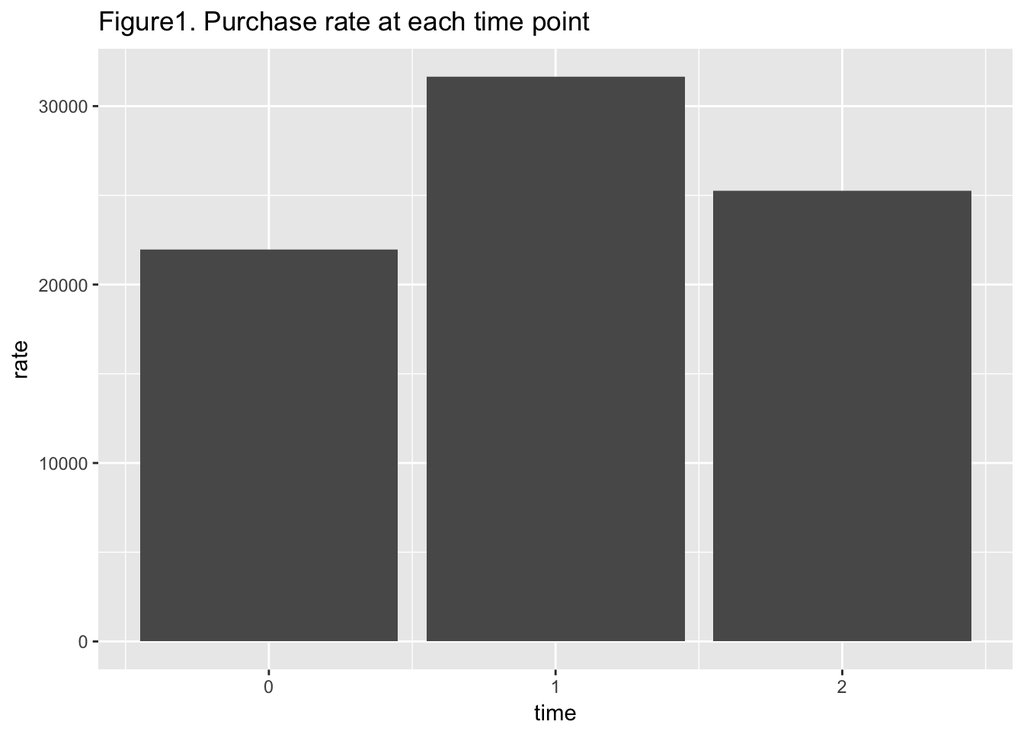

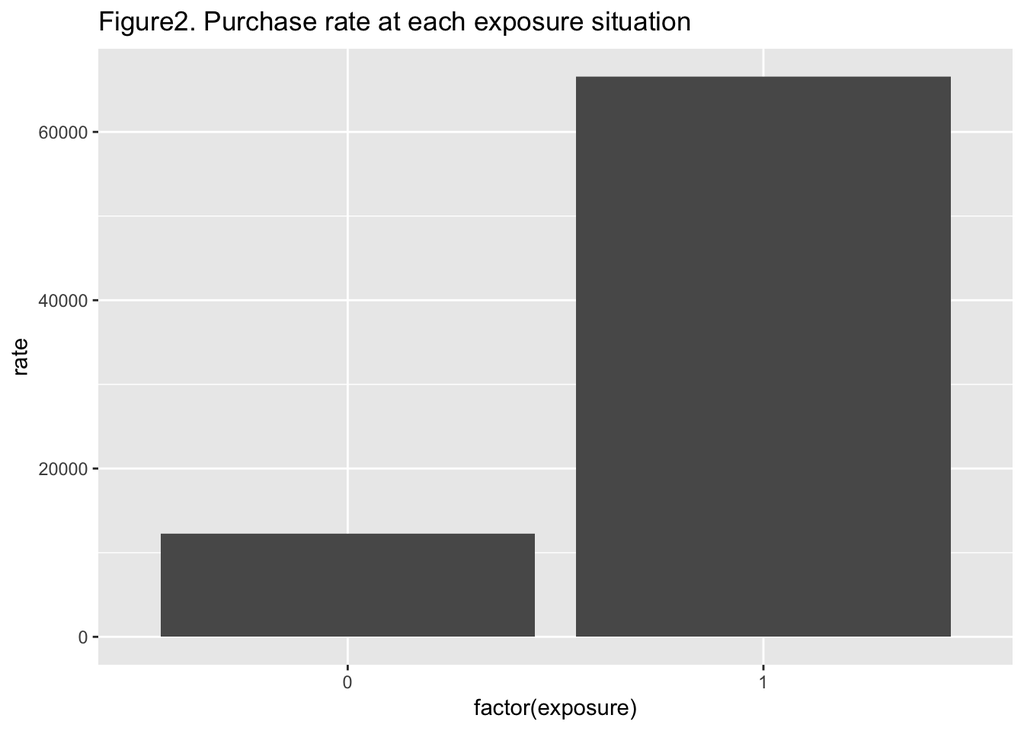

Conclusion

Reference

(1)Meyer-Waarden, L. (2008), “The Influence of Loyalty Program Membership on Customer Purchase Behavior,” European Journal of Marketing, 42, 87-114 (2)Yuping Liu. (2007), “The Long-Term Impact of Loyalty Programs on Consumer Purchase Behavior and Loyalty” American Marketing Association, 1547-7185 (3)Wilma E Waterlander. (2013), “Effects of different discount levels on healthy products coupled with a healthy choice label, special offer label or both: results from a web-based supermarket experiment”, International Journal of Behavior Nutrition and Physical Activity. (4)Berry, Michael J.A (1997). Data Mining Techniques For Marketing, Sales and Customer Support. Wiley. p. 10. (5)Bertrand, M.; Duflo, E.; Mullainathan, S. (2004). “How Much Should We Trust Differences-in-Differences Estimates?”. Quarterly Journal of Economics. 119 (1): 249–275.

Appendix

```
##    household_key                            category time      rate
## 1              1          Bakery items, ready to eat    0 0.6591928
## 2              1          Bakery items, ready to eat    1 0.4510740
## 3              1          Bakery items, ready to eat    2 0.3181818
## 4              1                        Canned Fruit    0 0.6278027
## 5              1                        Canned Fruit    1 0.4844869
## 6              1                        Canned Fruit    2 0.2386364
## 7              1  Canned select nutrients vegetables    1 0.1503580
## 8              1  Canned select nutrients vegetables    2 0.1590909
## 9              1 Canned soups, sauces, prepared food    0 0.8475336
## 10             1 Canned soups, sauces, prepared food    1 1.0859189
##    exposure
## 1         1
## 2         1
## 3         1
## 4         1
## 5         1
## 6         1
## 7         1
## 8         1
## 9         1
## 10        1
```

```
##
## Call:
## lm(formula = rate ~ time, data = bigdata)
##
## Residuals:
##     Min      1Q  Median      3Q     Max
## -0.4137 -0.3342 -0.2149  0.0362 28.6513
##
## Coefficients:
##             Estimate Std. Error t value Pr(>|t|)
## (Intercept) 0.309082   0.002356  131.19   <2e-16 ***
## time        0.092100   0.001996   46.15   <2e-16 ***
## ---
## Signif. codes:  0 '***' 0.001 '**' 0.01 '*' 0.05 '.' 0.1 ' ' 1
##
## Residual standard error: 0.6741 on 200699 degrees of freedom
## Multiple R-squared:  0.0105, Adjusted R-squared:  0.0105
## F-statistic:  2130 on 1 and 200699 DF,  p-value: < 2.2e-16
```

```
##
## Call:
## lm(formula = rate ~ exposure, data = bigdata)
##
## Residuals:
##     Min      1Q  Median      3Q     Max
## -0.4545 -0.3456 -0.1705  0.0322 28.5813
##
## Coefficients:
##             Estimate Std. Error t value Pr(>|t|)
## (Intercept) 0.206418   0.002734   75.49   <2e-16 ***
## exposure    0.264780   0.003260   81.23   <2e-16 ***
## ---
## Signif. codes:  0 '***' 0.001 '**' 0.01 '*' 0.05 '.' 0.1 ' ' 1
##
## Residual standard error: 0.6668 on 200699 degrees of freedom
## Multiple R-squared:  0.03183,    Adjusted R-squared:  0.03182
## F-statistic:  6598 on 1 and 200699 DF,  p-value: < 2.2e-16
```